# STAT 679 Final Project Milestone 2

Hari Krishna Boyapati

# Loading required packages

```r
library('tidyverse')
library("data.table")
```

```r
library(ggplot2)
library(magrittr)
library(plyr)
library(ggrepel)
library(dplyr)
library(plyr)
```

Reading data

```r
big_mac <- fread("big-mac-source-data-v2.csv")
head(big_mac,n = 10)
```

| name | iso_a3 | currency_code | local_price | dollar_ex | GDP_dollar | GDP_local | date |
| --- | --- | --- | --- | --- | --- | --- | --- |
| Argentina | ARG | ARS | 2.50 | 1.000000 | 8709.072 | 8709.072 | 2000-04-01 |
| Australia | AUS | AUD | 2.59 | 1.680000 | 21746.809 | 33698.764 | 2000-04-01 |
| Brazil | BRA | BRL | 2.95 | 1.790000 | 3501.438 | 6351.375 | 2000-04-01 |
| Canada | CAN | CAD | 2.85 | 1.470000 | 22340.553 | 33191.468 | 2000-04-01 |
| Switzerland | CHE | CHF | 5.90 | 1.700000 | 41859.215 | 62879.029 | 2000-04-01 |
| Chile | CHL | CLP | 1260.00 | 514.000000 | 5130.835 | 2610470.719 | 2000-04-01 |
| China | CHN | CNY | 9.90 | 8.280000 | 865.236 | 7162.571 | 2000-04-01 |
| Czech Republic | CZE | CZK | 54.37 | 39.100000 | 6333.862 | 218956.850 | 2000-04-01 |
| Denmark | DNK | DKK | 24.75 | 8.040000 | 33492.354 | 233650.703 | 2000-04-01 |
| Euro area | EUZ | EUR | 2.56 | 1.075269 | NA | NA | 2000-04-01 |

```r
big_mac <- fread("big-mac-source-data-v2.csv") %>%
    .[!is.na(local_price)] %>%                    # remove lines where the local price is missing
    .[,GDP_local := as.numeric(GDP_local)] %>%    # convert GDP to a number
    .[order(date, name)]
tail(big_mac,n = 10)
```

| name | iso_a3 | currency_code | local_price | dollar_ex | GDP_dollar | GDP_local | date |
| --- | --- | --- | --- | --- | --- | --- | --- |
| Sweden | SWE | SEK | 57.00 | 10.19785 | 60028.543 | 514838.80 | 2022-07-01 |
| Switzerland | CHE | CHF | 6.50 | 0.96845 | 93719.959 | 85645.59 | 2022-07-01 |
| Taiwan | TWN | TWD | 75.00 | 29.90750 | 33775.172 | 946498.54 | 2022-07-01 |
| Thailand | THA | THB | 128.00 | 36.61250 | 7336.086 | 231302.80 | 2022-07-01 |
| Turkey | TUR | TRY | 47.00 | 17.56500 | 9527.683 | 84481.34 | 2022-07-01 |
| United Arab Emirates | ARE | AED | 18.00 | 3.67305 | 42883.686 | 157490.34 | 2022-07-01 |
| United States | USA | USD | 5.15 | 1.00000 | 69231.400 | 69231.40 | 2022-07-01 |
| Uruguay | URY | UYU | 255.00 | 41.91000 | 16756.344 | 729194.22 | 2022-07-01 |
| Venezuela | VEN | VES | 10.00 | 5.67320 | 1685.657 | NA | 2022-07-01 |
| Vietnam | VNM | VND | 69000.00 | 23417.00000 | 3724.543 | 85420189.72 | 2022-07-01 |

Cleaning data and removing null values

```r
any(is.na(big_mac))
```

```
## [1] TRUE
```

```r
dim(big_mac)
```

```
## [1] 1946    8
```

```r
big_mac<- na.omit(big_mac)
any(is.na(big_mac))
```

```
## [1] FALSE
```

```r
dim(big_mac)
```

```
## [1] 1918    8
```

Now we have clean data without any NA values We have data for 72 countires, we will focus on few countries which have a high gdp and poluplation.

```r
big_mac_countries = c('ARG', 'AUS', 'BRA', 'GBR', 'CAN', 'CHL', 'CHN', 'CZE', 'DNK',
                      'EGY', 'HKG', 'HUN', 'IDN', 'ISR', 'JPN', 'MYS', 'MEX', 'NZL',
                      'NOR', 'PER', 'PHL', 'POL', 'RUS', 'SAU', 'SGP', 'ZAF', 'KOR',
                      'SWE', 'CHE', 'TWN', 'THA', 'TUR', 'ARE', 'USA', 'COL', 'CRI',
                      'PAK', 'LKA', 'UKR', 'URY', 'IND', 'VNM', 'GTM', 'HND', 'VEN',
                      'NIC', 'AZE', 'BHR', 'HRV', 'JOR', 'KWT', 'LBN', 'MDA', 'OMN',
                      'QAT', 'ROU', 'EUZ')
length(big_mac_countries)
```

```
## [1] 57
```

The price of big mac for each country is listed in it’s local currency, for uniformity, lets convert all the prices into single currencly, we will use USD as the base currency, since we have the exchange rate of each currency with respect to USD.

```r
big_mac$dollar_price<- big_mac$local_price/big_mac$dollar_ex
tail(big_mac)
```

| name | iso_a3 | currency_code | local_price | dollar_ex | GDP_dollar | GDP_local | date | dollar_price |
| --- | --- | --- | --- | --- | --- | --- | --- | --- |
| Thailand | THA | THB | 128.00 | 36.61250 | 7336.086 | 231302.80 | 2022-07-01 | 3.496074 |
| Turkey | TUR | TRY | 47.00 | 17.56500 | 9527.683 | 84481.34 | 2022-07-01 | 2.675776 |
| United Arab Emirates | ARE | AED | 18.00 | 3.67305 | 42883.686 | 157490.34 | 2022-07-01 | 4.900559 |
| United States | USA | USD | 5.15 | 1.00000 | 69231.400 | 69231.40 | 2022-07-01 | 5.150000 |
| Uruguay | URY | UYU | 255.00 | 41.91000 | 16756.344 | 729194.22 | 2022-07-01 | 6.084467 |
| Vietnam | VNM | VND | 69000.00 | 23417.00000 | 3724.543 | 85420189.72 | 2022-07-01 | 2.946577 |

#now we have price of big mac in each country in dollars Now let’s pick five base currencies : USD, EUR, GBP, JPY, CNY

```r
base_currencies = c('USD', 'EUR', 'GBP', 'JPY', 'CNY')
```

Big mac index in a simple method is basically ratio of price of Bigmac in local currency to the price in Base currency. lets calculate this by using group by filtering required columns

```r
big_mac_index = big_mac[
    !is.na(dollar_price) & iso_a3 %in% big_mac_countries
    ,.(date, iso_a3, currency_code, name, local_price, dollar_ex, dollar_price)]
tail(big_mac_index)
```

| date | iso_a3 | currency_code | name | local_price | dollar_ex | dollar_price |
| --- | --- | --- | --- | --- | --- | --- |
| 2022-07-01 | THA | THB | Thailand | 128.00 | 36.61250 | 3.496074 |
| 2022-07-01 | TUR | TRY | Turkey | 47.00 | 17.56500 | 2.675776 |
| 2022-07-01 | ARE | AED | United Arab Emirates | 18.00 | 3.67305 | 4.900559 |
| 2022-07-01 | USA | USD | United States | 5.15 | 1.00000 | 5.150000 |
| 2022-07-01 | URY | UYU | Uruguay | 255.00 | 41.91000 | 6.084467 |
| 2022-07-01 | VNM | VND | Vietnam | 69000.00 | 23417.00000 | 2.946577 |

Calculating big mac index

```r
for(currency in base_currencies) {
big_mac_index[
,
(currency) :=
dollar_price /
.SD[currency_code == currency]$dollar_price - 1,
by=date
]
}
big_mac_index[, (base_currencies) := round(.SD, 5L), .SDcols=base_currencies]
tail(big_mac_index)
```

| date | iso_a3 | currency_code | name | local_price | dollar_ex | dollar_price | USD | EUR | GBP | JPY | CNY |
| --- | --- | --- | --- | --- | --- | --- | --- | --- | --- | --- | --- |
| 2022-07-01 | THA | THB | Thailand | 128.00 | 36.61250 | 3.496074 | -0.32115 | -0.26631 | -0.21260 | 0.23586 | -0.01712 |
| 2022-07-01 | TUR | TRY | Turkey | 47.00 | 17.56500 | 2.675776 | -0.48043 | -0.43846 | -0.39735 | -0.05411 | -0.24773 |
| 2022-07-01 | ARE | AED | United Arab Emirates | 18.00 | 3.67305 | 4.900559 | -0.04844 | 0.02843 | 0.10373 | 0.73235 | 0.37774 |
| 2022-07-01 | USA | USD | United States | 5.15 | 1.00000 | 5.150000 | 0.00000 | 0.08078 | 0.15991 | 0.82053 | 0.44787 |
| 2022-07-01 | URY | UYU | Uruguay | 255.00 | 41.91000 | 6.084467 | 0.18145 | 0.27689 | 0.37037 | 1.15086 | 0.71058 |
| 2022-07-01 | VNM | VND | Vietnam | 69000.00 | 23417.00000 | 2.946577 | -0.42785 | -0.38163 | -0.33636 | 0.04162 | -0.17160 |

Now we have the raw index agianst five base currencies we have picked.

```r
#fwrite(big_mac_index, 'C:/Users/harik/Desktop/Course work/STAT 679/Final Project Milestone 2/big_mac_raw_index.csv')
```

Now lets calculate the GDP adjucted index

```r
big_mac_gdp_data = big_mac[GDP_local > 0]
head(big_mac_gdp_data)
```

| name | iso_a3 | currency_code | local_price | dollar_ex | GDP_dollar | GDP_local | date | dollar_price |
| --- | --- | --- | --- | --- | --- | --- | --- | --- |
| Argentina | ARG | ARS | 2.50 | 1.0000000 | 8709.072 | 8709.072 | 2000-04-01 | 2.500000 |
| Australia | AUS | AUD | 2.59 | 1.6800000 | 21746.809 | 33698.764 | 2000-04-01 | 1.541667 |
| Brazil | BRA | BRL | 2.95 | 1.7900000 | 3501.438 | 6351.375 | 2000-04-01 | 1.648045 |
| Britain | GBR | GBP | 1.90 | 0.6329114 | 28733.206 | 17755.606 | 2000-04-01 | 3.002000 |
| Canada | CAN | CAD | 2.85 | 1.4700000 | 22340.553 | 33191.468 | 2000-04-01 | 1.938776 |
| Chile | CHL | CLP | 1260.00 | 514.0000000 | 5130.835 | 2610470.719 | 2000-04-01 | 2.451362 |

```r
regression_countries = c('ARG', 'AUS', 'BRA', 'GBR', 'CAN', 'CHL', 'CHN', 'CZE', 'DNK',
                         'EGY', 'EUZ', 'HKG', 'HUN', 'IDN', 'ISR', 'JPN', 'MYS', 'MEX',
                         'NZL', 'NOR', 'PER', 'PHL', 'POL', 'RUS', 'SAU', 'SGP', 'ZAF',
                         'KOR', 'SWE', 'CHE', 'TWN', 'THA', 'TUR', 'USA', 'COL', 'PAK',
                         'IND', 'AUT', 'BEL', 'NLD', 'FIN', 'FRA', 'DEU', 'IRL', 'ITA',
                         'PRT', 'ESP', 'GRC', 'EST')
# in 2021, we added a number of additional countries to the adjusted index
regression_addons_2021 = c('ARE', 'CRI', 'LKA', 'UKR', 'URY', 'VNM', 'GTM', 'HND', 'NIC',
                           'AZE', 'BHR', 'HRV', 'JOR', 'KWT', 'MDA', 'OMN', 'QAT', 'ROU',
                           'SVK', 'SVN', 'LVA', 'LTU')
big_mac_gdp_data = big_mac_gdp_data[iso_a3 %in% regression_countries |
  (iso_a3 %in% regression_addons_2021 & date >= as.Date('2021-01-01'))
]

tail(big_mac_gdp_data)
```

| name | iso_a3 | currency_code | local_price | dollar_ex | GDP_dollar | GDP_local | date | dollar_price |
| --- | --- | --- | --- | --- | --- | --- | --- | --- |
| Thailand | THA | THB | 128.00 | 36.61250 | 7336.086 | 231302.80 | 2022-07-01 | 3.496074 |
| Turkey | TUR | TRY | 47.00 | 17.56500 | 9527.683 | 84481.34 | 2022-07-01 | 2.675776 |
| United Arab Emirates | ARE | AED | 18.00 | 3.67305 | 42883.686 | 157490.34 | 2022-07-01 | 4.900559 |
| United States | USA | USD | 5.15 | 1.00000 | 69231.400 | 69231.40 | 2022-07-01 | 5.150000 |
| Uruguay | URY | UYU | 255.00 | 41.91000 | 16756.344 | 729194.22 | 2022-07-01 | 6.084467 |
| Vietnam | VNM | VND | 69000.00 | 23417.00000 | 3724.543 | 85420189.72 | 2022-07-01 | 2.946577 |

Now we adjust the GDP with respect to Big mac price, which is done by dividing gdp in local currency by the exchange rate of dollars in terms of Big mac(price of big mac in local currency/price in the United states), this incorporates the purchasing power parity(ppp) in the perspective of big mac.

```r
big_mac_gdp_data %>%
    .[,GDP_bigmac := GDP_local / (local_price / .SD[iso_a3=='USA']$local_price), by=date]
tail(big_mac_gdp_data)
```

| name | iso_a3 | currency_code | local_price | dollar_ex | GDP_dollar | GDP_local | date | dollar_price | GDP_bigmac |
| --- | --- | --- | --- | --- | --- | --- | --- | --- | --- |
| Thailand | THA | THB | 128.00 | 36.61250 | 7336.086 | 231302.80 | 2022-07-01 | 3.496074 | 9306.324 |
| Turkey | TUR | TRY | 47.00 | 17.56500 | 9527.683 | 84481.34 | 2022-07-01 | 2.675776 | 9256.998 |
| United Arab Emirates | ARE | AED | 18.00 | 3.67305 | 42883.686 | 157490.34 | 2022-07-01 | 4.900559 | 45059.736 |
| United States | USA | USD | 5.15 | 1.00000 | 69231.400 | 69231.40 | 2022-07-01 | 5.150000 | 69231.400 |
| Uruguay | URY | UYU | 255.00 | 41.91000 | 16756.344 | 729194.22 | 2022-07-01 | 6.084467 | 14726.864 |
| Vietnam | VNM | VND | 69000.00 | 23417.00000 | 3724.543 | 85420189.72 | 2022-07-01 | 2.946577 | 6375.565 |

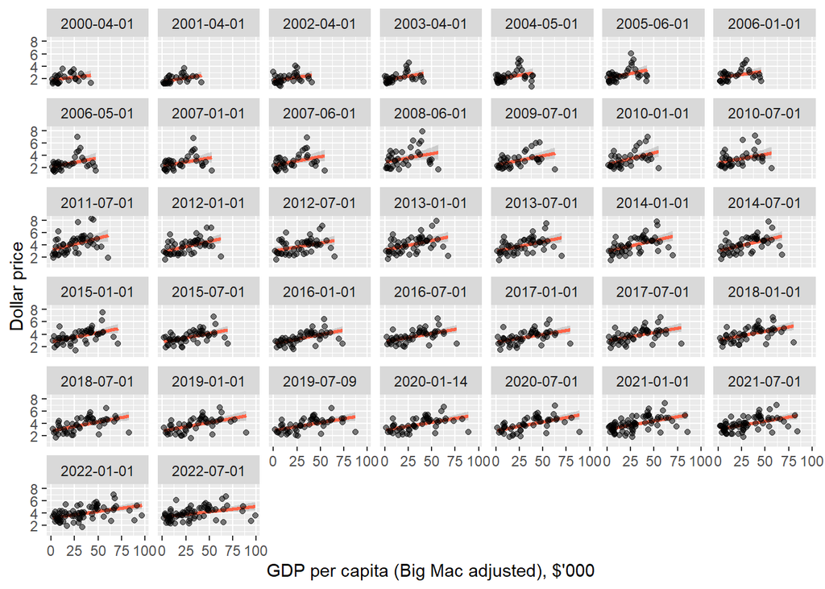

```r
ggplot(big_mac_gdp_data, aes(x=GDP_bigmac, y=dollar_price)) +
    facet_wrap(~date)+
    geom_smooth(method = lm, color='tomato') +
    geom_point(alpha=0.5) +
    scale_x_continuous(labels=function(x) {round(x / 1000)}) +
    labs(y="Dollar price", x="GDP per capita (Big Mac adjusted), $'000")
```

```r
big_mac_gdp_data[
    ,
    `:=`(
        adj_price=lm(dollar_price ~ GDP_bigmac) %>% predict
#         adj_price_USD=lm(dollar_price ~ GDP_dollar) %>% predict
    ),
    by = date]
tail(big_mac_gdp_data)
```

| name | iso_a3 | currency_code | local_price | dollar_ex | GDP_dollar | GDP_local | date | dollar_price | GDP_bigmac | adj_price |
| --- | --- | --- | --- | --- | --- | --- | --- | --- | --- | --- |
| Thailand | THA | THB | 128.00 | 36.61250 | 7336.086 | 231302.80 | 2022-07-01 | 3.496074 | 9306.324 | 3.505648 |
| Turkey | TUR | TRY | 47.00 | 17.56500 | 9527.683 | 84481.34 | 2022-07-01 | 2.675776 | 9256.998 | 3.504791 |
| United Arab Emirates | ARE | AED | 18.00 | 3.67305 | 42883.686 | 157490.34 | 2022-07-01 | 4.900559 | 45059.736 | 4.126598 |
| United States | USA | USD | 5.15 | 1.00000 | 69231.400 | 69231.40 | 2022-07-01 | 5.150000 | 69231.400 | 4.546401 |
| Uruguay | URY | UYU | 255.00 | 41.91000 | 16756.344 | 729194.22 | 2022-07-01 | 6.084467 | 14726.864 | 3.599789 |
| Vietnam | VNM | VND | 69000.00 | 23417.00000 | 3724.543 | 85420189.72 | 2022-07-01 | 2.946577 | 6375.565 | 3.454747 |

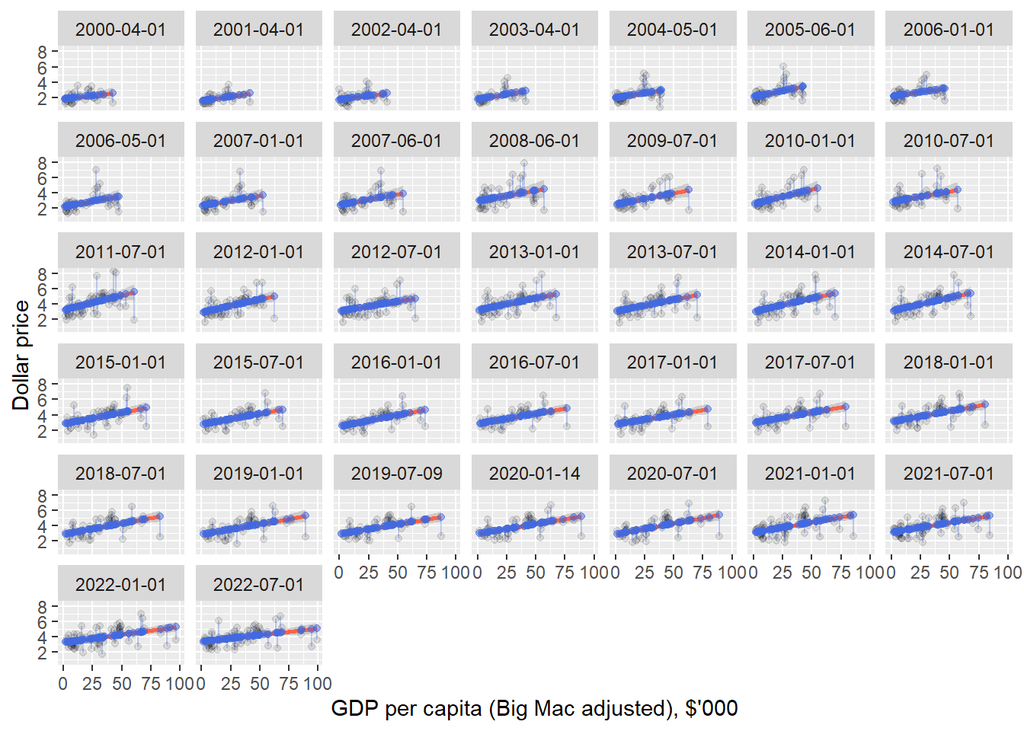

```r
ggplot(big_mac_gdp_data, aes(x=GDP_bigmac, y=dollar_price)) +
    facet_wrap(~date) +
    geom_smooth(method = lm, color='tomato') +
    geom_linerange(aes(ymin=dollar_price, ymax=adj_price), color='royalblue', alpha=0.3) +
    geom_point(alpha=0.1) +
    geom_point(aes(y=adj_price), color='royalblue', alpha=0.5) +
    scale_x_continuous(labels=function(x) {round(x / 1000)}) +
    labs(y="Dollar price", x="GDP per capita (Big Mac adjusted), $'000")
```

#Now we can calculate the adjusted big_mac index same as before

```r
big_mac_adj_index = big_mac_gdp_data[
    !is.na(dollar_price) &
    (
        iso_a3 %in% regression_countries |
        iso_a3 %in% regression_addons_2021 & date >= '2021-01-01'
    ) &
    iso_a3 %in% big_mac_countries
    ,.(date, iso_a3, currency_code, name, local_price, dollar_ex, dollar_price, GDP_bigmac, adj_price)]

for(currency in base_currencies) {
    big_mac_adj_index[
        ,                           # we don't want a subset, so our first argument is blank
        (currency) :=               # we'll add a new column named for the base set
            (                       # we divide the dollar price by the adjusted price to get
                dollar_price / adj_price  # the deviation from our expectation by
            ) /
                                    # the same figure from the *base currency*'s rowa\
            (
                .SD[currency_code == currency]$dollar_price /
                .SD[currency_code == currency]$adj_price
            ) -
            1,                      # one means parity (neither over- nor under-valued), so we subtract one
                                    # to get an over/under-valuation value
        by=date                     # and of course, we'll group these rows by date
    ]
}
big_mac_adj_index[, (base_currencies) := round(.SD, 5L), .SDcols=base_currencies]

tail(big_mac_adj_index)
```

| date | iso_a3 | currency_code | name | local_price | dollar_ex | dollar_price | GDP_bigmac | adj_price | USD | EUR | GBP | JPY | CNY |
| --- | --- | --- | --- | --- | --- | --- | --- | --- | --- | --- | --- | --- | --- |
| 2022-07-01 | THA | THB | Thailand | 128.00 | 36.61250 | 3.496074 | 9306.324 | 3.505648 | -0.11961 | -0.15486 | -0.06210 | 0.52797 | 0.02085 |
| 2022-07-01 | TUR | TRY | Turkey | 47.00 | 17.56500 | 2.675776 | 9256.998 | 3.504791 | -0.32602 | -0.35300 | -0.28199 | 0.16974 | -0.21849 |
| 2022-07-01 | ARE | AED | United Arab Emirates | 18.00 | 3.67305 | 4.900559 | 45059.736 | 4.126598 | 0.04837 | 0.00640 | 0.11686 | 0.81952 | 0.21563 |
| 2022-07-01 | USA | USD | United States | 5.15 | 1.00000 | 5.150000 | 69231.400 | 4.546401 | 0.00000 | -0.04003 | 0.06533 | 0.73557 | 0.15955 |
| 2022-07-01 | URY | UYU | Uruguay | 255.00 | 41.91000 | 6.084467 | 14726.864 | 3.599789 | 0.49213 | 0.43239 | 0.58961 | 1.58970 | 0.73019 |
| 2022-07-01 | VNM | VND | Vietnam | 69000.00 | 23417.00000 | 2.946577 | 6375.565 | 3.454747 | -0.24706 | -0.27720 | -0.19787 | 0.30679 | -0.12693 |

```r
#fwrite(big_mac_adj_index, 'C:/Users/harik/Desktop/Course work/STAT 679/Final Project Milestone 2/big_mac_adj_index.csv')
```

Merging both raw index and adjusted index into single dataframe

```r
big_mac_full_index = merge(big_mac_index, big_mac_adj_index,
      by=c('date', 'iso_a3', 'currency_code', 'name', 'local_price', 'dollar_ex', 'dollar_price'),
      suffixes=c('_raw', '_adjusted'),
      all.x=TRUE
     )
tail(big_mac_full_index)
```

| date | iso_a3 | currency_code | name | local_price | dollar_ex | dollar_price | USD_raw | EUR_raw | GBP_raw | JPY_raw | CNY_raw | GDP_bigmac | adj_price | USD_adjusted | EUR_adjusted | GBP_adjusted | JPY_adjusted | CNY_adjusted |
| --- | --- | --- | --- | --- | --- | --- | --- | --- | --- | --- | --- | --- | --- | --- | --- | --- | --- | --- |
| 2022-07-01 | TUR | TRY | Turkey | 47.00 | 17.56500 | 2.675776 | -0.48043 | -0.43846 | -0.39735 | -0.05411 | -0.24773 | 9256.998 | 3.504791 | -0.32602 | -0.35300 | -0.28199 | 0.16974 | -0.21849 |
| 2022-07-01 | TWN | TWD | Taiwan | 75.00 | 29.90750 | 2.507732 | -0.51306 | -0.47373 | -0.43520 | -0.11352 | -0.29498 | 64992.900 | 4.472789 | -0.50505 | -0.52486 | -0.47271 | -0.14097 | -0.42608 |
| 2022-07-01 | URY | UYU | Uruguay | 255.00 | 41.91000 | 6.084467 | 0.18145 | 0.27689 | 0.37037 | 1.15086 | 0.71058 | 14726.864 | 3.599789 | 0.49213 | 0.43239 | 0.58961 | 1.58970 | 0.73019 |
| 2022-07-01 | USA | USD | United States | 5.15 | 1.00000 | 5.150000 | 0.00000 | 0.08078 | 0.15991 | 0.82053 | 0.44787 | 69231.400 | 4.546401 | 0.00000 | -0.04003 | 0.06533 | 0.73557 | 0.15955 |
| 2022-07-01 | VNM | VND | Vietnam | 69000.00 | 23417.00000 | 2.946577 | -0.42785 | -0.38163 | -0.33636 | 0.04162 | -0.17160 | 6375.565 | 3.454747 | -0.24706 | -0.27720 | -0.19787 | 0.30679 | -0.12693 |
| 2022-07-01 | ZAF | ZAR | South Africa | 39.90 | 17.03625 | 2.342065 | -0.54523 | -0.50849 | -0.47251 | -0.17208 | -0.34155 | 13261.544 | 3.574340 | -0.42155 | -0.44471 | -0.38376 | 0.00394 | -0.32926 |

```r
#fwrite(big_mac_full_index, 'C:/Users/harik/Desktop/Course work/STAT 679/Final Project Milestone 2/big_mac_full_index.csv')
```

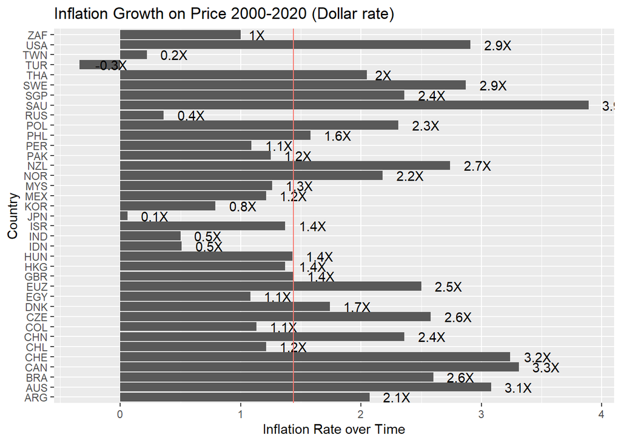

```r
df <- data.frame(matrix(ncol = 2, nrow = 0))
colnames(df)<- c("country","inflation")

for(i in regression_countries){
  df_temp <- big_mac_adj_index %>% filter(iso_a3 == i)
  temp <- df_temp$dollar_price[nrow(df_temp)]-df_temp$dollar_price[1]
  df[nrow(df)+1,] = c(i,temp)
}

df1<-df[1:37,]
df1$inflation<-as.numeric(df1$inflation)
df1$inflation<-round(df1$inflation,2)
plot<- ggplot(df1,aes(x = inflation, y = country)) +
  geom_col() +
  geom_text(aes(label = paste0(round(inflation, 1), "X")), hjust = -0.5) +
  geom_vline(aes(xintercept = median(inflation), colour = "red")) +
  theme(legend.position = "none") +
  labs(x = "Inflation Rate over Time",
       y = "Country",
       title = "Inflation Growth on Price 2000-2020 (Dollar rate)") +
  expand_limits(x = 3.5)
plot
```

[figure not shown]

```r
big_mac_adj_index %>%
  filter(date == max(date)) %>%
  select(name, dollar_price, adj_price) %>% ## prevent overlap data points
  distinct_all() %>%
  ggplot(aes(adj_price, dollar_price)) +
  geom_point() +
  geom_smooth(method = lm) +
  geom_text_repel(aes(label = name)) +
  labs(x = "Dollar GDP per capita",
       y = "Dollar Price",
       title = "GDP affects on Dollar Price of Big Mac Index")
```

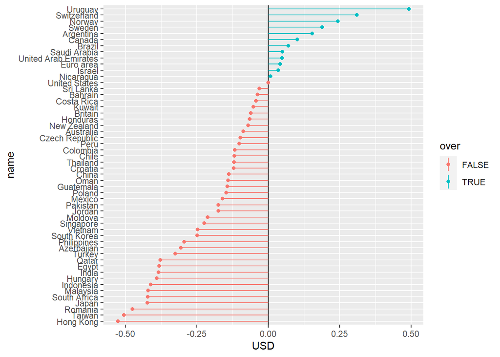

```r
latest_date = big_mac$date %>% max
to_plot = big_mac_adj_index[date == latest_date]
to_plot$name = factor(to_plot$name, levels=to_plot$name[order(to_plot$USD)])
ggplot(to_plot[, over := USD > 0], aes(x=name, y=USD, color=over)) +
    geom_hline(yintercept = 0) +
    geom_linerange(aes(ymin=0, ymax=USD)) +
    geom_point() +
    coord_flip()
```